# trial_rate_calc

Allison Davis Connelly

2025-07-09

# **Purpose**

For our CTmin and CTmax trials, we set the Arduino system to a desired rate of +/- 0.3°C/minute. However, factors such as temperature dispersal, ambient room temperature, and chilling mechanisms (see Methods in associated paper) may affect the actual rate experienced. Here, we calculated the average temperature rate for each trial type (CTmax, CTmin) and each species (mosquitofish, sailfin, swordtail). We then compare these averages to the goal rate (+/- 0.3°C/min), an alternative minimum rate (-0.1°C/min) and among species to confirm similar rate exposure.

# **Data**

All rates were calculated in excel (see supplementary data sheets in **Extras** folder) by fitting a simple linear model of temperature by second, then converted to degree/minute. We excluded one trial (Gambusia, CTmin, 7 Nov 23) as the data sheet only captured the second half of the trial.

All analyses were conducted using R version 4.4.2

## Load required libraries

Remove the ‘#’ prior to `install.packages` if it is the first time installing library.

```r
#install.packages("curl")             #v5.2.1
library(curl)
#install.packages("dplyr")            #v1.1.4
library(dplyr)
```

```r
#install.packages("tidyr")            #v1.3.1
library(tidyr)

#install.packages("gt")               #v0.11.1
library(gt)

#install.packages("summarytools")     #v1.1.4
library(summarytools)

#install.packages("ggplot2")          #v3.5.1
library(ggplot2)
```

## Read in data

```r
# OPTION 1: download 'rate_calc.csv' into working directory
rates <- read.csv("rate_calc.csv", header = TRUE, sep = ",", stringsAsFactors = TRUE)
head(rates)
```

```
##   Trial   Species  Size       Date     Rate                             file.id
## 1   max  gambusia  <NA> 11/28/2023 0.284479       adavis_ctmax_gambusia_28NOV23
## 2   max   sailfin  <NA>  12/2/2023 0.233267         adavis_ctmax_sailfin_2DEC23
## 3   max   sailfin  <NA> 11/19/2023 0.169185        adavis_ctmax_sailfin_19NOV23
## 4   max swordtail large 11/16/2023 0.277966          adavis_ctmax_swdlg_16NOV23
## 5   max  gambusia  <NA> 11/10/2023 0.256028 mckelvey_ctmax_mosquitofish_10nov23
## 6   max  gambusia  <NA> 11/17/2023 0.280690 mckelvey_ctmax_mosquitofish_17nov23
##    X X.1 X.2 X.3
## 1 NA  NA  NA
## 2 NA  NA  NA
## 3 NA  NA  NA
## 4 NA  NA  NA
## 5 NA  NA  NA
## 6 NA  NA  NA
```

```r
# OPTION 2: load from Github repository
rates <- curl("https://raw.githubusercontent.com/allisondavis/Temperature/refs/heads/main/rate_calc.csv")

rates <- read.csv(rates, header = TRUE, sep = ",", stringsAsFactors = TRUE)
head(rates)
```

```
##   Trial   Species  Size       Date     Rate                             file.id
## 1   max  gambusia  <NA> 11/28/2023 0.284479       adavis_ctmax_gambusia_28NOV23
## 2   max   sailfin  <NA>  12/2/2023 0.233267         adavis_ctmax_sailfin_2DEC23
## 3   max   sailfin  <NA> 11/19/2023 0.169185        adavis_ctmax_sailfin_19NOV23
## 4   max swordtail large 11/16/2023 0.277966          adavis_ctmax_swdlg_16NOV23
## 5   max  gambusia  <NA> 11/10/2023 0.256028 mckelvey_ctmax_mosquitofish_10nov23
## 6   max  gambusia  <NA> 11/17/2023 0.280690 mckelvey_ctmax_mosquitofish_17nov23
##    X X.1 X.2 X.3
## 1 NA  NA  NA
## 2 NA  NA  NA
## 3 NA  NA  NA
## 4 NA  NA  NA
## 5 NA  NA  NA
## 6 NA  NA  NA
```

```r
# One trial (Gambusia, CTmin, 7 Nov 23) only captured part of the excel sheet, so the rate calculated does not reflect the whole trial. We will remove this trial.

rates <- rates[-c(24),]

# Rename trial and species levels for more intuitive table labels
rates$Trial <- factor(rates$Trial,
                        levels = c("min", "max"),
                        labels = c("CTmin", "CTmax"))

rates$Species <- factor(rates$Species,
                        levels = c("swordtail", "sailfin", "gambusia"),
                        labels = c("Swordtail", "Sailfin", "Mosquitofish"))


# Will create a separate data set for CTmax and CTmin

max.rates <- rates[rates$Trial =="CTmax",]
min.rates <- rates[rates$Trial =="CTmin",]
```

# **Analysis**

## Summary statistics

**Rates by trial**

Average rates per trial type (CTmax, CTmin) for all species combined.

```r
#calculate average rate per trial type
trial.rates <- rates %>%
  group_by(Trial) %>%
  summarize(Rate=mean(Rate, na.rm=TRUE), .groups = "drop")

trial.rates
```

```
## # A tibble: 2 × 2
##   Trial    Rate
##   <fct>   <dbl>
## 1 CTmin -0.0972
## 2 CTmax  0.269
```

**Rates by species and trial**

Average rates per trail type (CTmax, CTmin) per species (mosquitofish, sailfin, swordtail)

```r
#calculate average rate per trial per species
trial.rates2 <- rates %>%
  group_by(Trial, Species) %>%
  summarize(trial.rate=mean(Rate, na.rm=TRUE),
            stand.dev = sd(Rate, na.rm=TRUE),
            min= min(Rate, na.rm = TRUE),
            Median= median(Rate, na.rm = TRUE),
            max= max(Rate, na.rm = TRUE),
            .groups = "drop")

trial.rates2
```

```
## # A tibble: 6 × 7
##   Trial Species      trial.rate stand.dev    min  Median     max
##   <fct> <fct>             <dbl>     <dbl>  <dbl>   <dbl>   <dbl>
## 1 CTmin Swordtail       -0.0943   0.0116  -0.105 -0.0978 -0.0723
## 2 CTmin Sailfin         -0.0929   0.00838 -0.104 -0.0931 -0.0806
## 3 CTmin Mosquitofish    -0.110    0.00424 -0.115 -0.108  -0.107
## 4 CTmax Swordtail        0.272    0.00577  0.265  0.271   0.280
## 5 CTmax Sailfin          0.252    0.0517   0.169  0.282   0.290
## 6 CTmax Mosquitofish     0.284    0.0190   0.256  0.284   0.309
```

## Normality

**Results:** Despite normality, we will use non-parametric tests for our subsequent comparisons due to a small sample size (16 trials in CTmax and 14 trials in CTmin).

```r
#check normality
normal <- rates %>%
  group_by(Trial, Species) %>%
summarize(statistic =shapiro.test(Rate)$statistic,
          p.value = shapiro.test(Rate)$p.value)
normal #normal for all trials and all species
```

```
## # A tibble: 6 × 4
## # Groups:   Trial [2]
##   Trial Species      statistic p.value
##   <fct> <fct>            <dbl>   <dbl>
## 1 CTmin Swordtail        0.827  0.101
## 2 CTmin Sailfin          0.901  0.418
## 3 CTmin Mosquitofish     0.800  0.115
## 4 CTmax Swordtail        0.929  0.576
## 5 CTmax Sailfin          0.807  0.0920
## 6 CTmax Mosquitofish     0.950  0.736
```

**Histograms for CTmax and CTmin trials**

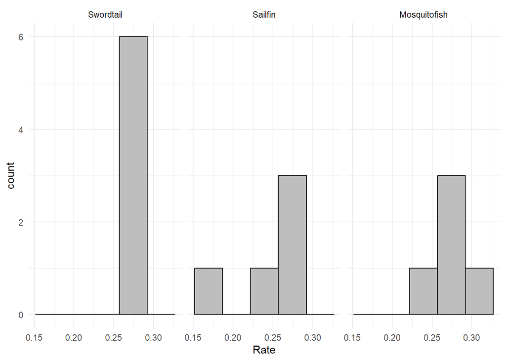

```r
# 5 bins chosen following Sturges's Rule
hist.max <- ggplot(max.rates, aes(x = Rate)) +
  geom_histogram(bins = 5, fill = "grey", color = "black") +
  facet_wrap(~Species) +
  theme_minimal()
hist.max
```

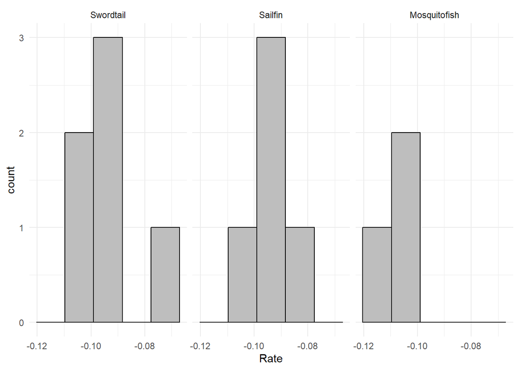

```r
hist.min <- ggplot(min.rates, aes(x = Rate)) +
  geom_histogram(bins = 5, fill = "grey", color = "black") +
  facet_wrap(~Species) +
  theme_minimal()
hist.min
```

## Comparison to target rate

Testing if CTmax trials met a rate of 0.3°C/minute and if CTmin trails met a rate of -0.3°C/minute. Will do this for all trails first, then repeat within species.

```r
# All CTmax and all CTmin trials
wilcox.test(max.rates$Rate, mu=0.3) #significant (p<0.001)
```

```
##
##  Wilcoxon signed rank exact test
##
## data:  max.rates$Rate
## V = 1, p-value = 6.104e-05
## alternative hypothesis: true location is not equal to 0.3
```

```r
wilcox.test(min.rates$Rate, mu=-0.3) #significant (p<0.001)
```

```
##
##  Wilcoxon signed rank exact test
##
## data:  min.rates$Rate
## V = 105, p-value = 0.0001221
## alternative hypothesis: true location is not equal to -0.3
```

```r
# CTmax by species
wt <- max.rates %>%
  group_by(Species) %>%
  summarize(statistic =wilcox.test(Rate, mu=0.3)$statistic,
          p.value = wilcox.test(Rate, mu=0.3)$p.value)

wt
```

```
## # A tibble: 3 × 3
##   Species      statistic p.value
##   <fct>            <dbl>   <dbl>
## 1 Swordtail            0  0.0313
## 2 Sailfin              0  0.0625
## 3 Mosquitofish         1  0.125
```

```r
### Only swordtail CTmax trial rates differed from 0.3degC/min (p=0.031).




# CTmin by species
wt2 <- min.rates %>%
  group_by(Species) %>%
  summarize(statistic =wilcox.test(Rate, mu=-0.3)$statistic,
          p.value = wilcox.test(Rate, mu=-0.3)$p.value)

wt2
```

```
## # A tibble: 3 × 3
##   Species      statistic p.value
##   <fct>            <dbl>   <dbl>
## 1 Swordtail           21  0.0313
## 2 Sailfin             15  0.0625
## 3 Mosquitofish         6  0.25
```

```r
### Only swordtail CTmin trial rates differed from -0.3degC/min (p=0.031).
```

**Alternative CTmin rate**

Due to the difficulties in reaching a -0.3°C/min rate, a common alternative rate for CTmin trials is -0.1°C/min. We will repeat the comparisons above but with a -0.1°C/min rate instead.

```r
# All CTmin trials
wilcox.test(min.rates$Rate, mu=-0.1) #not significant (p=0.502)
```

```
##
##  Wilcoxon signed rank exact test
##
## data:  min.rates$Rate
## V = 64, p-value = 0.5016
## alternative hypothesis: true location is not equal to -0.1
```

```r
# CTmin by species
wt3 <- min.rates %>%
  group_by(Species) %>%
  summarize(statistic =wilcox.test(Rate, mu=-0.1)$statistic,
          p.value = wilcox.test(Rate, mu=-0.1)$p.value)

wt3
```

```
## # A tibble: 3 × 3
##   Species      statistic p.value
##   <fct>            <dbl>   <dbl>
## 1 Swordtail           16   0.313
## 2 Sailfin             14   0.125
## 3 Mosquitofish         0   0.25
```

```r
### No CTmin rates in any species differ from -0.1degC/min.
```

## Differences between species

Since swordtail trails differed from the target rate but not mosquitofish and sailfin, we wanted to compare the rates among the species to see if they differed from each other.

```r
kruskal.test(Rate~Species, data=max.rates) #not significant (p=0.295)
```

```
##
##  Kruskal-Wallis rank sum test
##
## data:  Rate by Species
## Kruskal-Wallis chi-squared = 2.4397, df = 2, p-value = 0.2953
```

```r
kruskal.test(Rate~Species, data=min.rates) #significant (p=0.034)
```

```
##
##  Kruskal-Wallis rank sum test
##
## data:  Rate by Species
## Kruskal-Wallis chi-squared = 6.7886, df = 2, p-value = 0.03356
```

```r
# Since CTmin rates did differ between the species, we will perform pairwise comparisons using a Benjamini-Hochberg p adjustment.

pw <- pairwise.wilcox.test(min.rates$Rate, min.rates$Species, p.adjust.method = "BH")

pw_df <- pw$p.value %>%
  as.data.frame() %>%
  tibble::rownames_to_column("group1") %>%
  pivot_longer(
    -group1,
    names_to = "group2",
    values_to = "p_adj") %>%
  filter(!is.na(p_adj)) %>%
  arrange(group1, group2)
pw_df
```

```
## # A tibble: 3 × 3
##   group1       group2     p_adj
##   <chr>        <chr>      <dbl>
## 1 Mosquitofish Sailfin   0.0536
## 2 Mosquitofish Swordtail 0.0536
## 3 Sailfin      Swordtail 0.662
```

```r
### Looks like mosquitofish CTmin trials are marginally (p=0.054) different than sailfin and swordtail.
```

# **Summary**

**Trial rates compared to set rate**

The goal rate for both CTmax and CTmin trials was +/- 0.3°C/min. Both CTmax and CTmin trials were significantly different than the target rate. When separated by species, only swordtail CTmax and CTmin trials were significantly different than the target rate.

When using the alternate CTmin rate of -0.1°C/min, there were no significant differences for any species.

**Rates among species**

We also compared rates among the species to determine if one species experienced a significantly different rate compared to the others, regardless of target rate. We did not find any differences for CTmax trials but did find a significant difference in CTmin trials. When followed up with a pairwise test (with a Benjamini-Hochberg p adjustment), we see that mosquitofish trials are marginally different than sailfin and swordtail (p=0.054).